# Assignment 2

### 1. Display the first 10 rows of the dataset using `kable()` function.

```r
# load dataset
# data_url = 'https://raw.githubusercontent.com/rfordatascience/tidytuesday/master/data/2018/2018-11-20/thanksgiving_meals.csv'
data_url = './thanksgiving_meals.csv'
meals = read_csv(data_url)
knitr::kable(meals[1:10, ])
```

| id | celebrate | main_dish | main_dish_other | main_prep | main_prep_other | stuffing | stuffing_other | cranberry | cranberry_other | gravy | side1 | side2 | side3 | side4 | side5 | side6 | side7 | side8 | side9 | side10 | side11 | side12 | side13 | side14 | side15 | pie1 | pie2 | pie3 | pie4 | … |
| --- | --- | --- | --- | --- | --- | --- | --- | --- | --- | --- | --- | --- | --- | --- | --- | --- | --- | --- | --- | --- | --- | --- | --- | --- | --- | --- | --- | --- | --- | --- |
| 4337954960 | Yes | Turkey | NA | Baked | NA | Bread-based | NA | None | NA | Yes | NA | Carrots | NA | NA | NA | NA | Green beans/green bean casserole | Macaroni and cheese | Mashed potatoes | NA | NA | NA | Yams/sweet potato casserole | NA | NA | Apple | NA | NA | NA | … |
| 4337951949 | Yes | Turkey | NA | Baked | NA | Bread-based | NA | Other (please specify) | Homemade cranberry gelatin ring | Yes | NA | NA | NA | Corn | NA | NA | Green beans/green bean casserole | Macaroni and cheese | Mashed potatoes | Rolls/biscuits | NA | Vegetable salad | Yams/sweet potato casserole | Other (please specify) | Asian vinagrette salad | Apple | NA | NA | Chocolate | … |
| 4337935621 | Yes | Turkey | NA | Roasted | NA | Rice-based | NA | Homemade | NA | Yes | Brussel sprouts | Carrots | Cauliflower | Corn | Cornbread | NA | NA | NA | Mashed potatoes | Rolls/biscuits | NA | Vegetable salad | NA | NA | NA | Apple | NA | Cherry | NA | … |
| 4337933040 | Yes | Turkey | NA | Baked | NA | Bread-based | NA | Homemade | NA | Yes | Brussel sprouts | NA | NA | NA | Cornbread | NA | NA | NA | Mashed potatoes | Rolls/biscuits | NA | Vegetable salad | Yams/sweet potato casserole | NA | NA | NA | NA | NA | NA | … |
| 4337931983 | Yes | Tofurkey | NA | Baked | NA | Bread-based | NA | Canned | NA | Yes | Brussel sprouts | NA | NA | NA | Cornbread | NA | NA | NA | Mashed potatoes | Rolls/biscuits | Squash | Vegetable salad | Yams/sweet potato casserole | NA | NA | Apple | NA | NA | NA | … |
| 4337929779 | Yes | Turkey | NA | Roasted | NA | Rice-based | NA | Homemade | NA | Yes | Brussel sprouts | Carrots | Cauliflower | Corn | Cornbread | Fruit salad | Green beans/green bean casserole | Macaroni and cheese | Mashed potatoes | Rolls/biscuits | Squash | Vegetable salad | Yams/sweet potato casserole | NA | NA | NA | NA | NA | NA | … |
| 4337924420 | Yes | Turkey | NA | Baked | NA | Bread-based | NA | Canned | NA | Yes | NA | NA | NA | NA | NA | Fruit salad | Green beans/green bean casserole | NA | Mashed potatoes | Rolls/biscuits | NA | NA | Yams/sweet potato casserole | NA | NA | Apple | NA | NA | NA | … |
| 4337916002 | Yes | Turkey | NA | Baked | NA | Rice-based | NA | Homemade | NA | Yes | NA | Carrots | NA | NA | NA | NA | NA | NA | NA | NA | NA | NA | NA | NA | NA | NA | NA | NA | Chocolate | … |
| 4337914977 | Yes | Turkey | NA | Roasted | NA | Bread-based | NA | Canned | NA | Yes | Brussel sprouts | NA | NA | Corn | Cornbread | NA | Green beans/green bean casserole | NA | Mashed potatoes | Rolls/biscuits | Squash | NA | NA | NA | NA | Apple | Buttermilk | NA | NA | … |
| 4337899817 | Yes | Other (please specify) | Turkey and Ham | Baked | NA | Bread-based | NA | Other (please specify) | Both Canned and Homemade | Yes | Brussel sprouts | Carrots | NA | NA | NA | NA | Green beans/green bean casserole | NA | Mashed potatoes | Rolls/biscuits | NA | NA | Yams/sweet potato casserole | NA | NA | NA | Buttermilk | NA | NA | … |

### 2. Using `skim()` display the summary of variables

```r
skimr::skim(meals)
```

Data summary

| Name | meals |
| --- | --- |
| Number of rows | 1058 |
| Number of columns | 65 |
| _______________________ |  |
| Column type frequency: |  |
| character | 64 |
| numeric | 1 |
| ________________________ |  |
| Group variables | None |

**Variable type: character**

| skim_variable | n_missing | complete_rate | min | max | empty | n_unique | whitespace |
| --- | --- | --- | --- | --- | --- | --- | --- |
| celebrate | 0 | 1.00 | 2 | 3 | 0 | 2 | 0 |
| main_dish | 84 | 0.92 | 6 | 22 | 0 | 8 | 0 |
| main_dish_other | 1023 | 0.03 | 4 | 85 | 0 | 32 | 0 |
| main_prep | 84 | 0.92 | 5 | 22 | 0 | 5 | 0 |
| main_prep_other | 1007 | 0.05 | 1 | 33 | 0 | 32 | 0 |
| stuffing | 84 | 0.92 | 4 | 22 | 0 | 4 | 0 |
| stuffing_other | 1022 | 0.03 | 4 | 46 | 0 | 29 | 0 |
| cranberry | 84 | 0.92 | 4 | 22 | 0 | 4 | 0 |
| cranberry_other | 1033 | 0.02 | 3 | 61 | 0 | 24 | 0 |
| gravy | 84 | 0.92 | 2 | 3 | 0 | 2 | 0 |
| side1 | 903 | 0.15 | 15 | 15 | 0 | 1 | 0 |
| side2 | 816 | 0.23 | 7 | 7 | 0 | 1 | 0 |
| side3 | 970 | 0.08 | 11 | 11 | 0 | 1 | 0 |
| side4 | 594 | 0.44 | 4 | 4 | 0 | 1 | 0 |
| side5 | 823 | 0.22 | 9 | 9 | 0 | 1 | 0 |
| side6 | 843 | 0.20 | 11 | 11 | 0 | 1 | 0 |
| side7 | 372 | 0.65 | 32 | 32 | 0 | 1 | 0 |
| side8 | 852 | 0.19 | 19 | 19 | 0 | 1 | 0 |
| side9 | 241 | 0.77 | 15 | 15 | 0 | 1 | 0 |
| side10 | 292 | 0.72 | 14 | 14 | 0 | 1 | 0 |
| side11 | 887 | 0.16 | 6 | 6 | 0 | 1 | 0 |
| side12 | 849 | 0.20 | 15 | 15 | 0 | 1 | 0 |
| side13 | 427 | 0.60 | 27 | 27 | 0 | 1 | 0 |
| side14 | 947 | 0.10 | 22 | 22 | 0 | 1 | 0 |
| side15 | 947 | 0.10 | 4 | 78 | 0 | 89 | 0 |
| pie1 | 544 | 0.49 | 5 | 5 | 0 | 1 | 0 |
| pie2 | 1023 | 0.03 | 10 | 10 | 0 | 1 | 0 |
| pie3 | 945 | 0.11 | 6 | 6 | 0 | 1 | 0 |
| pie4 | 925 | 0.13 | 9 | 9 | 0 | 1 | 0 |
| pie5 | 1022 | 0.03 | 13 | 13 | 0 | 1 | 0 |
| pie6 | 1019 | 0.04 | 8 | 8 | 0 | 1 | 0 |
| pie7 | 1024 | 0.03 | 5 | 5 | 0 | 1 | 0 |
| pie8 | 716 | 0.32 | 5 | 5 | 0 | 1 | 0 |
| pie9 | 329 | 0.69 | 7 | 7 | 0 | 1 | 0 |
| pie10 | 906 | 0.14 | 12 | 12 | 0 | 1 | 0 |
| pie11 | 1018 | 0.04 | 4 | 4 | 0 | 1 | 0 |
| pie12 | 987 | 0.07 | 22 | 22 | 0 | 1 | 0 |
| pie13 | 987 | 0.07 | 5 | 46 | 0 | 61 | 0 |
| dessert1 | 948 | 0.10 | 13 | 13 | 0 | 1 | 0 |
| dessert2 | 1042 | 0.02 | 8 | 8 | 0 | 1 | 0 |
| dessert3 | 930 | 0.12 | 8 | 8 | 0 | 1 | 0 |
| dessert4 | 986 | 0.07 | 11 | 11 | 0 | 1 | 0 |
| dessert5 | 867 | 0.18 | 10 | 10 | 0 | 1 | 0 |
| dessert6 | 854 | 0.19 | 7 | 7 | 0 | 1 | 0 |
| dessert7 | 1015 | 0.04 | 5 | 5 | 0 | 1 | 0 |
| dessert8 | 792 | 0.25 | 9 | 9 | 0 | 1 | 0 |
| dessert9 | 955 | 0.10 | 13 | 13 | 0 | 1 | 0 |
| dessert10 | 763 | 0.28 | 4 | 4 | 0 | 1 | 0 |
| dessert11 | 924 | 0.13 | 22 | 22 | 0 | 1 | 0 |
| dessert12 | 924 | 0.13 | 3 | 59 | 0 | 92 | 0 |
| prayer | 99 | 0.91 | 2 | 3 | 0 | 2 | 0 |
| travel | 107 | 0.90 | 59 | 80 | 0 | 4 | 0 |
| watch_program | 556 | 0.47 | 13 | 13 | 0 | 1 | 0 |
| kids_table_age | 107 | 0.90 | 2 | 13 | 0 | 12 | 0 |
| hometown_friends | 107 | 0.90 | 2 | 3 | 0 | 2 | 0 |
| friendsgiving | 107 | 0.90 | 2 | 3 | 0 | 2 | 0 |
| black_friday | 107 | 0.90 | 2 | 3 | 0 | 2 | 0 |
| work_retail | 107 | 0.90 | 2 | 3 | 0 | 2 | 0 |
| work_black_friday | 988 | 0.07 | 2 | 13 | 0 | 3 | 0 |
| community_type | 110 | 0.90 | 5 | 8 | 0 | 3 | 0 |
| age | 33 | 0.97 | 3 | 7 | 0 | 4 | 0 |
| gender | 33 | 0.97 | 4 | 6 | 0 | 2 | 0 |
| family_income | 33 | 0.97 | 12 | 20 | 0 | 11 | 0 |
| us_region | 59 | 0.94 | 7 | 18 | 0 | 9 | 0 |

**Variable type: numeric**

| skim_variable | n_missing | complete_rate | mean | sd | p0 | p25 | p50 | p75 | p100 | hist |
| --- | --- | --- | --- | --- | --- | --- | --- | --- | --- | --- |
| id | 0 | 1 | 4336731188 | 493783.4 | 4335894916 | 4336339486 | 4336796628 | 4337012140 | 4337954960 | ▅▃▇▂▂ |

The variables related to the types of main dish, the region variable, and the diversity of side dishes and desserts could be useful for the task to predict a family income based on their menu. The variables related to income ranges and diversity of the dishes could be useful for the task to predict a community type or us_region based on their menu.

### 3. Use `fct_reorder` and `parse_number` functions to create a factor variable `family_income`.

```r
meals2 = meals %>%
  mutate(family_income = na_if(family_income, "Prefer not to answer")) %>%
  mutate(family_income = fct_reorder(family_income, parse_number(family_income)))
```

### 4. What is the number of people who celebrate?

Among the 1,058 respondents who participated in the SurveyMonkey poll, the number of people who celebrate Thanksgiving is 980.

```r
table(meals2$celebrate)
```

```
##
##  No Yes
##  78 980
```

### 5. What are categories and insights for each main dish served and the method it is prepared?

```r
# drop NAs or uninformative rows
tmp = meals2 %>%
  select(id, main_dish, main_prep) %>%
  drop_na() %>%
  filter(main_dish != "I don't know" &
           main_dish != "Other (please specify)" &
           main_prep != "I don't know" &
           main_prep != "Other (please specify)")
table(tmp$main_dish, tmp$main_prep)
```

```
##
##              Baked Fried Roasted
##   Chicken        4     2       4
##   Ham/Pork      22     0       5
##   Roast beef     3     2       5
##   Tofurkey      14     0       4
##   Turducken      0     0       3
##   Turkey       422    41     351
```

The categories of the main dishes served are Turkey, Turducken, Tofurkey, Roast Beef, Ham/Pork and Chicken, which are prepared in three major methods including baking, frying and roasting. We can see that most of the respondents prefer to Turkey as the main dish. For the respondents choosing Turkey, the prepared methods for the main dish primarily include baking and roasting.

### 6. Create 3 different data viz showing insights for main dish served and the method. Provide your own legend and use themes.

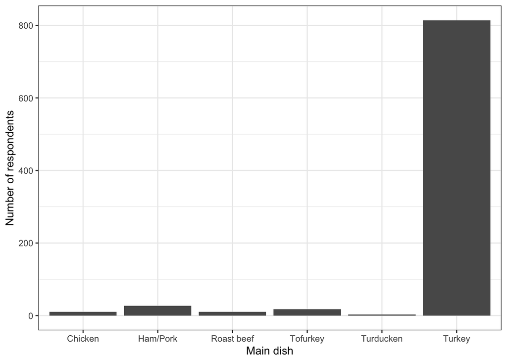

```r
ggplot(tmp, aes(main_dish)) +
  geom_bar() +
  xlab("Main dish") + ylab("Number of respondents") +
  theme_bw()
```

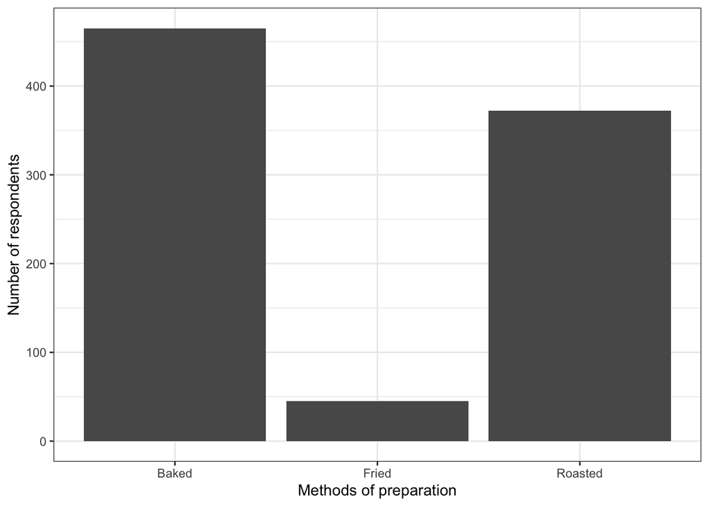

```r
ggplot(tmp, aes(main_prep)) +
  geom_bar() +
  xlab("Methods of preparation") + ylab("Number of respondents") +
  theme_bw()
```

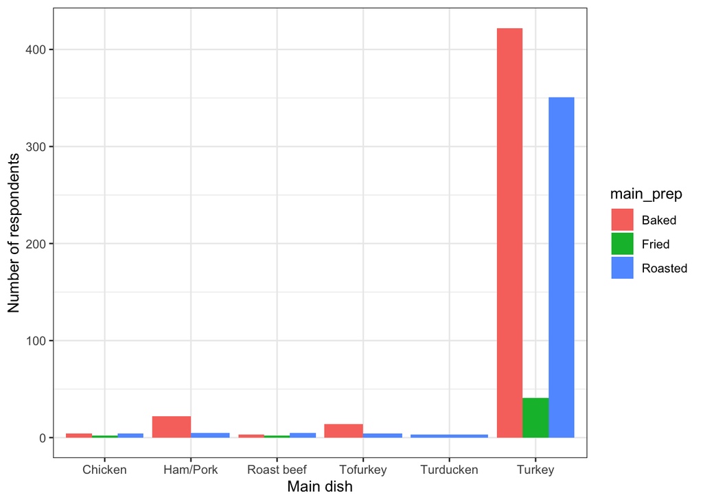

```r
ggplot(tmp, aes(main_dish)) +
  geom_bar(aes(fill = main_prep), position = "dodge") +
    xlab("Main dish") + ylab("Number of respondents") +
  theme_bw()
```

### 7. How many use cranberry sauce? How many use gravy?

```r
# cranberry sauce
sum(na.omit(meals2$cranberry != 'None'))
```

```
## [1] 828
```

```r
# gravy
table(meals2$gravy)
```

```
##
##  No Yes
##  82 892
```

The number of respondents who use cranberry sauce and gravy is 828 and 892, respectively.

### 8-9. What is the distribution of those who celebrate across income ranges. Create a data viz and explain each insight.

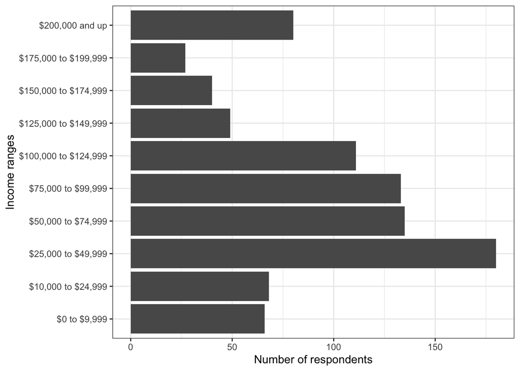

```r
meals2 %>%
  filter(!is.na(family_income)) %>%
  ggplot(aes(y = family_income)) +
  geom_bar() +
  ylab("Income ranges") + xlab("Number of respondents") +
  theme_bw()
```

From the above figure, we observe that the family income of the respondents is primarily between $25,000 and $124,999. The number of respondents across the different income ranges achieves the highest in the income range of $25,000~$49,999.

### 10. Use the following code to create a new data set and explain what it does.

```r
meals3 = meals2 %>%
  select(id, starts_with("side"),
         starts_with("pie"),
         starts_with("dessert")) %>%
  select(-side15, -pie3, -dessert12) %>%
  gather(type, value, -id) %>%
  filter(!is.na(value),
         !value %in% c("None", "Other (please specify)")) %>%
  mutate(type = str_remove(type, "\\d+"))
```

Four main steps are performed on the `meals2` data: (1) select the `id` variable and the variables that have the column name staring with `side` (except `side15`), `pie` (except `pie3`) and `dessert` (except `dessert12`); (2) transform the selected data in wide form to a long data.frame; (3) drop the rows where the `value` variable are NA or uninformative; (4) remove the digits in the `type` variable.

### 11-12. Install package `widyr` and use `pairwise_cor()` function. Explain what it does and use the function for the new dataset.

```r
# install.packages("widyr")
library(widyr)
pairwise_cor(meals3, value, id, sort = TRUE)
```

```
## # A tibble: 7,832 x 3
##    item1               item2               correlation
##    <chr>               <chr>                     <dbl>
##  1 Cookies             Brownies                  0.411
##  2 Brownies            Cookies                   0.411
##  3 Sweet Potato        Macaroni and cheese       0.365
##  4 Macaroni and cheese Sweet Potato              0.365
##  5 Rolls/biscuits      Mashed potatoes           0.341
##  6 Mashed potatoes     Rolls/biscuits            0.341
##  7 Peach cobbler       Sweet Potato              0.339
##  8 Sweet Potato        Peach cobbler             0.339
##  9 Pumpkin             Mashed potatoes           0.290
## 10 Mashed potatoes     Pumpkin                   0.290
## # … with 7,822 more rows
```

### 13. Use `lm()` or `randomForest()` function to build a model that predict a family income based on data in the dataset. Compare 3 models using different set of input variables or different number of variables. Explain your choice of variables and which model is best.

```r
library(randomForest)
# computed variables for use in models
side = is.na(meals2 %>% select(starts_with("side"))) + 0
pie = is.na(meals2 %>% select(starts_with("pie"))) + 0
dessert = is.na(meals2 %>% select(starts_with("dessert"))) + 0
side_num = rowSums(side) # number of side dishes
pie_num = rowSums(pie) # number of pies
dessert_num = rowSums(dessert) # number desserts

# selected variables
vars0 = c("id", "family_income", "celebrate",
          "main_dish", "community_type", "us_region")
mealdata0 = meals2 %>%
  select(all_of(vars0)) %>%
  mutate(side_num_v = side_num,
         pie_num_v = pie_num,
         dessert_num_v = dessert_num) %>%
  drop_na()

# split the data (20% for testing)
set.seed(1234)
idx = sample(1:nrow(mealdata0), size = 0.2 * nrow(mealdata0), replace = F)
data_train = mealdata0[-idx, ]
data_test = mealdata0[idx, ]

# build models
m1 = randomForest(family_income~celebrate+main_dish+community_type+us_region+
                    side_num_v+pie_num_v+dessert_num_v, data = data_train)
m2 = randomForest(family_income~community_type+us_region+
                    side_num_v+pie_num_v+dessert_num_v, data = data_train)
m3 = randomForest(family_income~celebrate+main_dish+community_type+us_region,
                  data = data_train)
m1_pred = predict(m1, data_test)
m2_pred = predict(m2, data_test)
m3_pred = predict(m3, data_test)
cat("model 1 accuracy: ", mean(m1_pred == data_test$family_income))
```

```
## model 1 accuracy:  0.154321
```

```r
cat("model 2 accuracy: ", mean(m2_pred == data_test$family_income))
```

```
## model 2 accuracy:  0.1481481
```

```r
cat("model 3 accuracy: ", mean(m3_pred == data_test$family_income))
```

```
## model 3 accuracy:  0.1234568
```